# Machine-Learning-vol.02-単回帰分析

## 2.1 今回のストーリー

さて､本章から機械学習の理論を詳しく学んでいきます｡最初に扱うのは**単回帰分析**という手法で､前章で紹介した**回帰**の一種です｡回帰は**教師あり学習**の手法のひとつで､**目的変数が連続値**であることが特徴でした｡単回帰は､その回帰の中でも**ひとつの説明変数のみで目的変数を予測すること**を目指す手法です｡

視覚的には､これは下図のように**散布図上のデータ点に最もよく当てはまる直線（回帰直線）を求める**ことを意味します｡非常にシンプルな手法ですが､シンプルであるがゆえに高い汎用性があり､実際の分析でもあらゆる場面で役立ちます｡まずはここから押さえていきましょう｡

[figure not shown]

第2章の舞台は**喫茶店**です｡今回は､この喫茶店のオーナーが**機械学習によるデータ分析を用いて､自分が抱える問題を解決していく過程**を体験していきましょう｡みなさんには､このストーリーに沿って**単回帰分析**を学びながら､**｢自分の仕事や研究に置き換えたら､どんな利用が出来るだろう？｣**ということを考えて進めていただきたいと思います｡

### *分析ストーリー: アイスコーヒーの需要予測*

> *東京都内にとある**喫茶店**がありました｡この**喫茶店**は､**商品の在庫管理**について悩みを抱えていました｡具体的には､**販売するアイスコーヒーの注文数が日によって大きくばらついてしまっていたために､在庫切れや在庫余りが頻繁に起こっていたのです**｡ たとえば､**注文が多すぎると在庫切れを起こして､せっかく来店してくれたお客さんを逃してしまいます**｡一方､**注文が少なすぎると在庫が倉庫に収まりきらなくなり､材料の多くを廃棄しなくてはならなくなります**｡そのため､何とかして**毎週の最適な仕入れ量を予測したい**と思っていました｡そのとき､オーナーは機械学習でアイスコーヒーの需要を予測する回帰モデルを構築すれば､材料の最適な仕入れ量がある程度わかるようになるかもしれないと考えました｡*

[figure not shown]

## 2.2 データの準備

まず初めに､分析の対象となるデータを読み込みましょう｡

### Excelによる作成

今回は､サンプルデータとして､単回帰の練習のために扱いやすいデータセットを作成しました｡ここからは､このデータが以下のようなストーリーで得られたとして､操作を続けていきましょう｡

> *オーナーは**機械学習**を利用するにあたって､**予測に用いる説明変数として何を利用するべきか**を考えました｡そして､経験から**アイスコーヒーの売上個数がその日の気温に大きく影響を受けること**に気付いたオーナーは､過去の売上データと**気象庁提供の気温データ**を照らし合わせて､**Excel**で簡単なデータセットを作成してみました｡下図にその表が示してあります｡**MAX_TEMP**はその日の最高気温､**N_COFFEE**はその日に売れたアイスコーヒーの個数を表しています｡つまりは､このデータは**教師ありデータ**で､目的変数がとある日のアイスコーヒーの売上個数で､説明変数が対応する日の最高気温であるというわけです｡このデータを分析することで､**天気予報であらかじめ知ることが出来る将来の最高気温から､その日のアイスコーヒーの売上を予測すること**を試みました｡*

#### 参考資料

[気象庁: "過去の気象データ検索"](http://www.data.jma.go.jp/obd/stats/etrn/index.php?sess=6ef525a9cdef28cea634ce58ca736e68)  
[総務省: "オープンデータ戦略の推進"](http://www.soumu.go.jp/menu_seisaku/ictseisaku/ictriyou/opendata/opendata02.html)

[figure not shown]

### Pandasによる読み込み

それでは早速､**作成したデータを分析にかける準備を整えていきましょう**｡まずは､作成した**Excelファイル**を**Jupyter Notebook**に読み込みます｡これによって､**Excelファイルに記されたデータをPythonで分析できるようになります**｡読み込みは､Excelのような**数表**を扱うライブラリである**pandas**の､ **read_excel()** 関数で実行できます（データが**csvファイル**として保存してある場合は**read_csv()** 関数）｡`()` の中には､**読み込みたいファイルのパス**を指定します｡起動しているJpyter Notebookと同じディレクトリにファイル保存している場合は､ファイル名を指定するだけです｡

また､ファイルはpandasの**DataFrame型**として読み込まれます｡

```python
# Excelファイルの読み込み
# ファイルはこのnotebookと同じディレクトリを
import pandas as pd
df = pd.read_excel('n_coffee vs temp.xlsx')

# csvファイルとして保存してある場合はこちらを利用
# df = pd.read_csv('n_coffee vs temp.csv')
```

```python
# 正しく読み込まれたことを確認
# .head()とすると､初めの5行だけ表示できる
df.head()
```

|  | MAX_TEMP | N_COFFEE |
| --- | --- | --- |
| 0 | 27 | 167 |
| 1 | 17 | 80 |
| 2 | 21 | 98 |
| 3 | 30 | 167 |
| 4 | 28 | 124 |

### NumPyによる変換

次に､pandasの**DataFrame型**にまとめられたデータを､numpyの**array型**に変換します｡なぜそうするのかというと､**機械学習**のライブラリである**scikit-learn**がarray型にしか対応していないからです｡

まずは､作成した**DataFrame**から指定の変数を取り出します｡

```python
# DataFrameから最高気温の列だけを取り出す
# locメソッドで列を指定できます
df.loc[:, ['MAX_TEMP']].head()
```

|  | MAX_TEMP |
| --- | --- |
| 0 | 27 |
| 1 | 17 |
| 2 | 21 |
| 3 | 30 |
| 4 | 28 |

次に､得られたデータを**array型**に変換します｡今回は最高気温から売上個数を予測するので､最高気温を**説明変数 X** ､売上個数を**目的変数 y** とします｡

```python
# 最高気温のデータをarrayに変換
import numpy as np
X = np.array(df.loc[:, ['MAX_TEMP']])
```

```python
# 変換されたことを確認
# 長いので､初めの5つだけ表示
X[:5]
```

```
array([[27],
       [17],
       [21],
       [30],
       [28]])
```

```python
# 売上個数のデータをarray型に変換
y = np.array(df.loc[:, ['N_COFFEE']])
```

```python
# 変換されたことを確認
# 長いので､初めの5つだけ表示
y[:5]
```

```
array([[167],
       [ 80],
       [ 98],
       [167],
       [124]])
```

さて､ここまでの作業でデータを分析にかける準備が整いました｡みなさんのPCにExcelやcsvの数表ファイルがあれば､同様の手順で読み込ませることができます｡ぜひ､試してみてください｡

## 2.3 データの観察

データ分析の最初のステップは**データの観察**です｡データの観察には手順があり､まず初めに**グラフでデータ全体を眺めて**､次に**数値指標で細かくチェックします**｡この順序を守ることが非常に重要で､分析の効率を大きく高めることに繋がります｡

### 手順1. グラフで全体的な傾向を捉える

それでは早速､グラフを出力してみましょう｡まずはここで､**データの全体的な傾向を視覚的に捉えます**｡なぜそうするのかというと､**数値の羅列をひとつひとつ眺めていても､全体的な傾向を掴むのは非常に難しいからです**｡まずは全体の傾向をざっくりと掴んで､分析の方針にアタリをつけていきましょう｡細かい数値は､傾向を掴んだその後で､確認のために見ていけば良いのです｡

さて､今回はデータの可視化をするにあたって､**散布図**というグラフを利用します｡散布図とは､**2つの変数の関係性を可視化するためのグラフ**です｡今回の例で言えば横軸に**最高気温**､縦軸に**売上個数**をそれぞれ取り､両者の関係性を可視化しています｡

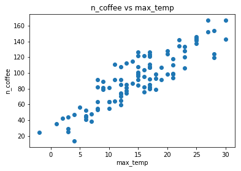

```python
# 散布図を出力
# 直線的な関係が確認できる
import matplotlib.pyplot as plt
% matplotlib inline
plt.scatter(X, y)                   # 散布図を表示
plt.title('n_coffee vs max_temp')   # タイトルを表示
plt.xlabel('max_temp')              # x軸のラベルを表示
plt.ylabel('n_coffee')              # y軸のラベルを表示
plt.show()                          # 指定した内容でグラフを出力
```

さて､散布図を出力した結果､**最高気温**と**売上個数**の間には**直線的な関係**があることがわかりました｡この時点で､**｢売上個数の予測は､単回帰分析で実現できるのではないか？｣**という**仮説**が立ちます｡このように仮説を立てると､その後の方針が明確になり､分析がスムーズになります｡

### 手順2: 数値指標で細かいチェックをする

さて､大まかな方針が立ったところで数値指標のチェックに移りましょう｡ここでやりたいことは､**確認された傾向がどれほどのものかを細かく評価すること**です｡今回の例ですと､**散布図で確認できた売上個数と最高気温の直線的な関係性がどれほど強いものなのか**を評価することになります｡**直線的な傾向の強さ**を表す数値指標として**相関係数**というものがありますので､今回はそれをチェックしましょう｡

#### 相関係数 $r$

相関係数は上述の通り､**直線的な傾向の強さを表す数値指標**です｡詳細な背景については後回しにして､まずは評価のしかただけ覚えてください（詳しくは**統計解析**の講座をご覧ください）｡

相関係数は､ **$-1 \leqq r \leqq +1$ の範囲で値を取り**､ $+1$ に近いほど**｢正の相関がある（右上がりの直線上にまとまっている）｣**という意味になり､逆に $-1$ に近いほど**｢負の相関が強い（右下がりの直線上にまとまっている）｣**という意味になります｡また､その中間である $0$ に近いほど**｢直線的な関係性はない（まったく直線上にまとまっていない）｣**という意味になります｡これを見ることで､**2変数の直線的な関係性を精査できます**｡また､評価の目安は以下の図を参考にしてください｡

[figure not shown]

#### 相関係数行列

変換ができたところで相関係数を出力しましょう｡相関係数は､pandasの**corr()**関数で確認することができますが､その際は**相関係数行列**の形で出力されます｡相関係数行列とは､**すべての変数の組み合わせに対して相関係数を並べただけの行列**です｡下図のような構造になっていて､今回確認したい相関係数は **(0, 1) 成分**または **(1, 0) 成分**として格納されています｡ちなみに､**対角成分には $x$ と $x$ の相関係数や $y$ と $y$ の相関係数が入っていて､これらは必然的に $1$ になります**｡

[figure not shown]

```python
# 相関係数行列を確認
df.corr()
```

|  | MAX_TEMP | N_COFFEE |
| --- | --- | --- |
| MAX_TEMP | 1.000000 | 0.889654 |
| N_COFFEE | 0.889654 | 1.000000 |

出力を見ると､相関係数は**約0.890**であることがわかりました｡先程の評価目安に基づけば､**売上個数と最高気温の間には非常に強い相関がある**ということになります｡相関が強いとされる $±0.7$ をゆうに超えているので､ **これだけ強い相関があれば､単回帰を行うことは十分に有益そうです**｡

#### ※注意※

相関係数は､性質上**曲線的な関係性を見落とします**｡相関係数はあくまでも2変数間の**｢直線的な｣**関係性の強さを表すものであり､曲線的な関係性の強さまでは拾えません｡なので､**相関係数を算出する際には､必ず散布図で｢直線的な｣関係性が強いことを確認してからにしてください**｡でないと､曲線的な関係性を見落としてしまう可能性が出てきます｡

[figure not shown]